# Understanding Samples

## From last time…

**Example:** Gambler’s ruin

Two gamblers, A and B, make a sequence of $1 bets. In each bet, gambler A has probability p of winning, and gambler B has probability q = 1 − p of winning. Gambler A starts with i dollars and gambler B starts with N − i dollars; the total wealth between the two remains constant since every time A loses a dollar, the dollar goes to B, and vice versa. The game ends when either A or B is ruined, i.e., when the random walk reaches 0 or N.

Note: `rbinom(1, n = 1, p = 0.5)` will simulate a coin flip where `1` denotes heads and `p` is the probability of heads.

First, let’s simulate a single run of this game.

```r
N <- 20   # set total wealth
p <- 0.5  # set prob. A wins a bet
i <- 10   # A's initial wealth
bets <- 0 # initializing no. of bets
while(i > 0 & (N - i) > 0) {
  bets <- bets + 1
  outcome <- rbinom(1, n = 1, p = p)
  if (outcome == 1) {
    i <- i + 1
  } else {
    i <- i - 1
  }
}
i    # A's wealth
```

```
[1] 20
```

```r
bets # No. of bets made
```

```
[1] 66
```

Next, we can run this a large number of times to see how many times A wins. The proportion estimates the probability that A wins.

```r
N <- 20   # set total wealth
p <- 0.5  # set prob. A wins a bet
ntrial <- 10000 # number of simulations
a_wins <- numeric(ntrial)
n_bets <- numeric(ntrial)
for(j in 1:ntrial) {
  bets <- 0 # initializing no. of bets
  i <- 10   # A's initial wealth
  while(i > 0 & (N - i) > 0) {
    bets <- bets + 1
    outcome <- rbinom(1, n = 1, p = p)
    if (outcome == 1) {
      i <- i + 1
    } else {
      i <- i - 1
    }
  }

  a_wins[j] <- i == N    # A's wealth
  n_bets[j] <- bets # No. of bets made
}
mean(a_wins)
```

```
[1] 0.5067
```

Finally, we can see how long we would expect the game to run by storing the number of bets for each trial, and looking at it’s distribution.

```r
library(tidyverse)
ggplot(data.frame(bets = n_bets), aes(x = bets)) +
  geom_histogram()

mean(n_bets)
```

[output not shown]

## Set up

```r
library(tidyverse)
library(readr)
```

## Data

[SF OpenData](https://data.sfgov.org/) is a website where the City and County of San Francisco make some of their data publicly available. One of the data sets contains compensation data for employees of the City. These include medical professionals at City-run hospitals, police officers, fire fighters, transportation workers, elected officials, and all other employees of the City.

```r
sf2016 <- read_csv("https://github.com/cmsc205/notes/raw/master/day18/sf2016.csv")
glimpse(sf2016)
```

```
Observations: 44,566
Variables: 22
$ YearType              <chr> "Calendar", "Calendar"...
$ Year                  <int> 2016, 2016, 2016, 2016...
$ OrganizationGroupCode <chr> "06", "01", "01", "06"...
$ OrganizationGroup     <chr> "General Administratio...
$ DepartmentCode        <chr> "CAT", "FIR", "POL", "...
$ Department            <chr> "City Attorney", "Fire...
$ UnionCode             <chr> "311", "798", "911", "...
$ Union                 <chr> "Municipal Attorneys' ...
$ JobFamilyCode         <chr> "8100", "H000", "Q000"...
$ JobFamily             <chr> "Legal & Court", "Fire...
$ JobCode               <chr> "8177", "H002", "Q002"...
$ Job                   <chr> "Attorney (Civil/Crimi...
$ EmployeeIdentifier    <int> 22886, 50903, 35179, 4...
$ Salaries              <dbl> 199462.62, 84419.58, 1...
$ Overtime              <dbl> 0.00, 25195.54, 13929....
$ OtherSalaries         <dbl> 5489.25, 9306.90, 1958...
$ TotalSalary           <dbl> 204951.87, 118922.02, ...
$ Retirement            <dbl> 36773.64, 16507.44, 20...
$ HealthDental          <dbl> 13890.50, 16822.93, 13...
$ OtherBenefits         <dbl> 11843.94, 1995.16, 255...
$ TotalBenefits         <dbl> 62508.08, 35325.53, 37...
$ TotalCompensation     <dbl> 267459.95, 154247.55, ...
```

Financial packages in a calendar year can sometimes be hard to understand as they depend on the date of hire, whether the employee is changing jobs within the City, and so on. For example, the lowest values in the Total Compensation column look a little strange.

```r
sf2016 %>%
  select(Job, TotalCompensation, everything()) %>%
  arrange(TotalCompensation) %>%
  head()
```

| Job | TotalCompensation | YearType | Year | OrganizationGroupCode | OrganizationGroup | DepartmentCode | Department | UnionCode | Union | JobFamilyCode | JobFamily | JobCode | EmployeeIdentifier | Salaries | Overtime | OtherSalaries | TotalSalary | Retirement | HealthDental | OtherBenefits | TotalBenefits |
| --- | --- | --- | --- | --- | --- | --- | --- | --- | --- | --- | --- | --- | --- | --- | --- | --- | --- | --- | --- | --- | --- |
| City Planning Intern | -731.64 | Calendar | 2016 | 06 | General Administration & Finance | CPC | City Planning | 021 | Prof & Tech Engineers - Miscellaneous, Local 21 | 5200 | Professional Engineering | 5276 | 29841 | 0 | 0 | 0.00 | 0.00 | 0.00 | 100.62 | -832.26 | -731.64 |
| Special Nurse | -366.47 | Calendar | 2016 | 04 | Community Health | DPH | Public Health | 791 | SEIU - Staff and Per Diem Nurses, Local 1021 | 2300 | Nursing | P103 | 25635 | 0 | 0 | 0.00 | 0.00 | -366.47 | 0.00 | 0.00 | -366.47 |
| EMT/Paramedic/Firefighter | -72.30 | Calendar | 2016 | 01 | Public Protection | FIR | Fire Department | 798 | Firefighters - Miscellaneous, Local 798 | H000 | Fire Services | H003 | 35238 | 0 | 0 | 0.00 | 0.00 | 0.00 | 0.00 | -72.30 | -72.30 |
| Payroll Clerk | 0.04 | Calendar | 2016 | 03 | Human Welfare & Neighborhood Development | DSS | Human Services | 790 | SEIU - Miscellaneous, Local 1021 | 1200 | Personnel | 1220 | 47549 | 0 | 0 | 0.00 | 0.00 | 0.00 | 0.00 | 0.04 | 0.04 |
| Executive Secretary 3 | 1.97 | Calendar | 2016 | 06 | General Administration & Finance | BOS | Board of Supervisors | 022 | Prof & Tech Engineers - Personnel, Local 21 | 1400 | Clerical, Secretarial & Steno | 1454 | 35749 | 0 | 0 | 1.83 | 1.83 | 0.00 | 0.00 | 0.14 | 0.14 |
| Senior Telephone Operator | 4.27 | Calendar | 2016 | 04 | Community Health | DPH | Public Health | 790 | SEIU - Miscellaneous, Local 1021 | 1700 | Computer Operatns & Repro Svcs | 1708 | 53545 | 0 | 0 | 3.96 | 3.96 | 0.00 | 0.00 | 0.31 | 0.31 |

To avoid these complications, we’ll only focus on employees who had at least the equivalent of a half-time job for the whole year. At a minimum wage of about $10 per hour, and 20 hours per week for 52 weeks, that’s a salary of about $10,000.

```r
sf2016 <- filter(sf2016, TotalCompensation >= 10000)
glimpse(sf2016)
```

```
Observations: 40,063
Variables: 22
$ YearType              <chr> "Calendar", "Calendar"...
$ Year                  <int> 2016, 2016, 2016, 2016...
$ OrganizationGroupCode <chr> "06", "01", "01", "06"...
$ OrganizationGroup     <chr> "General Administratio...
$ DepartmentCode        <chr> "CAT", "FIR", "POL", "...
$ Department            <chr> "City Attorney", "Fire...
$ UnionCode             <chr> "311", "798", "911", "...
$ Union                 <chr> "Municipal Attorneys' ...
$ JobFamilyCode         <chr> "8100", "H000", "Q000"...
$ JobFamily             <chr> "Legal & Court", "Fire...
$ JobCode               <chr> "8177", "H002", "Q002"...
$ Job                   <chr> "Attorney (Civil/Crimi...
$ EmployeeIdentifier    <int> 22886, 50903, 35179, 4...
$ Salaries              <dbl> 199462.62, 84419.58, 1...
$ Overtime              <dbl> 0.00, 25195.54, 13929....
$ OtherSalaries         <dbl> 5489.25, 9306.90, 1958...
$ TotalSalary           <dbl> 204951.87, 118922.02, ...
$ Retirement            <dbl> 36773.64, 16507.44, 20...
$ HealthDental          <dbl> 13890.50, 16822.93, 13...
$ OtherBenefits         <dbl> 11843.94, 1995.16, 255...
$ TotalBenefits         <dbl> 62508.08, 35325.53, 37...
$ TotalCompensation     <dbl> 267459.95, 154247.55, ...
```

## Populations and parameters

**Population:** all units of interest

**Parameter:** a numeric summary of the population

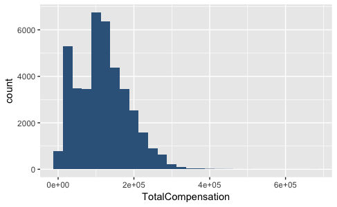

```r
sf2016 %>%
  ggplot(aes(x = TotalCompensation)) +
  geom_histogram(binwidth = 25000, fill = "steelblue4")
```

When we have the entire population, it’s very easy to find the parameter value

```r
sf2016 %>%
  summarize(median = median(TotalCompensation),
            mean = mean(TotalCompensation))
```

| median | mean |
| --- | --- |
| 113535.8 | 117010.3 |

## Estimating a parameter from a sample

In practice, we often only have information about some subset of a population, called a **sample**. To mimic this, let’s draw a random sample of 500 employees. (Note: this sample will change each time you run the code, don’t panic!)

```r
our_sample <- sf2016 %>%
  sample_n(size = 500)
```

Let’s take a peek at our sample

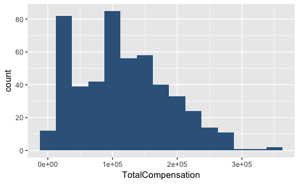

```r
our_sample %>%
  ggplot(aes(x = TotalCompensation)) +
  geom_histogram(binwidth = 25000, fill = "steelblue4")
```

Now, we want to estimate median total compensation

```r
median(our_sample$TotalCompensation)
```

[output not shown]

But this will change each time we draw a new sample!

### Pulling a sample up by its bootstraps

A better estimate of the median total compensation would be given by an interval that accounts for the **sampling variability**. To do this, we will use the **bootstrap**.

Idea:

- Treat the original sample as if it were the population.
- Draw from the sample, at random with replacement, the same number of times as the original sample size.
- Calculate the statistic of interest from this new bootstrap sample.

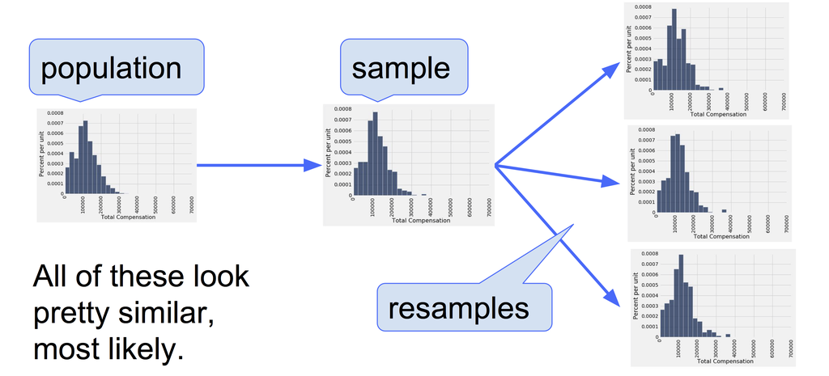

#### Your task:

Using a `for` loop, take 5,000 bootstrap resamples from `our_sample`, calculate the median total compensation, and store is in vector `medians`. Note, the `sample` function allows you to take a sample from a vector of a given `size`, and `replace = TRUE` makes it with replacement.

Let’s examine the bootstrap distribution

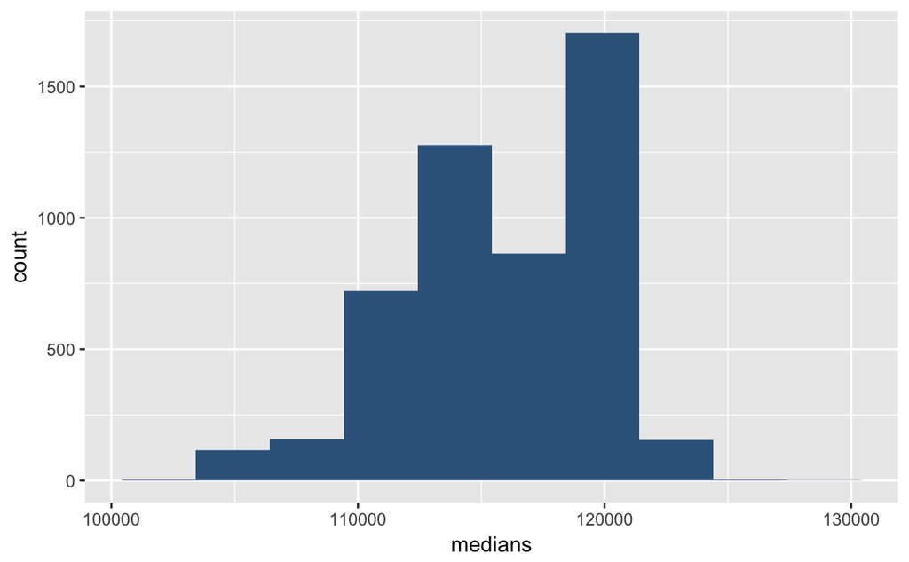

#### Building an interval estimate

Once we have a large number of bootstrap medians, we can construct a so-called **95% confidence interval** by peeling off the 2.5th and 97.5th percentile (i.e. we look at the central 95% of bootstrap means).

```
    2.5%    97.5%
107004.5 121838.7
```

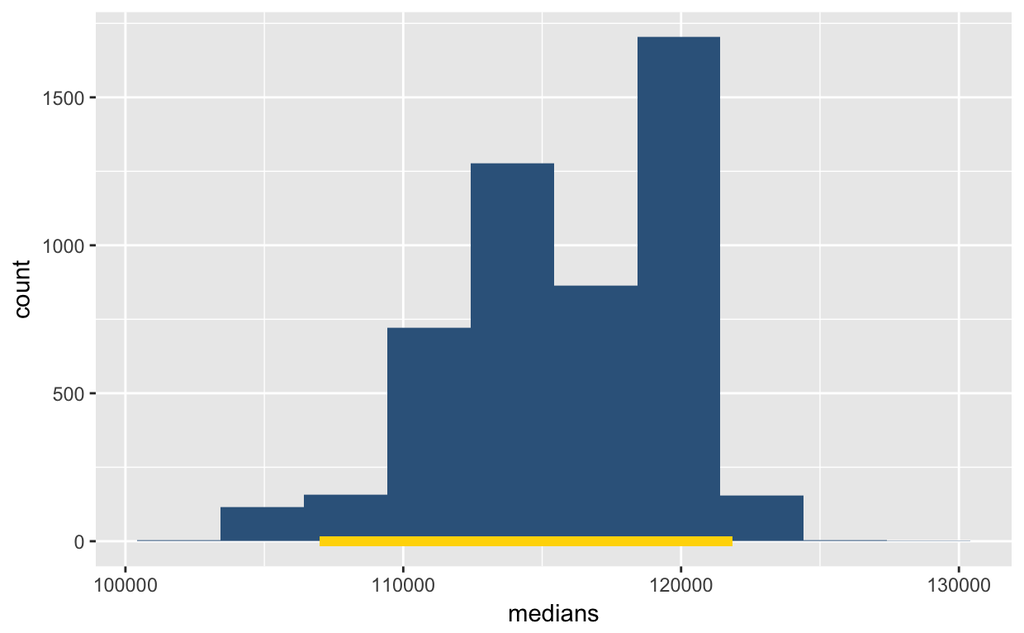

If instead of a 95% confidence interval, we wanted an 80% confidence interval, then we simply choose different quantiles that take the middle 80% of bootstrap statistics.

```
     10%      90%
110904.1 120684.4
```

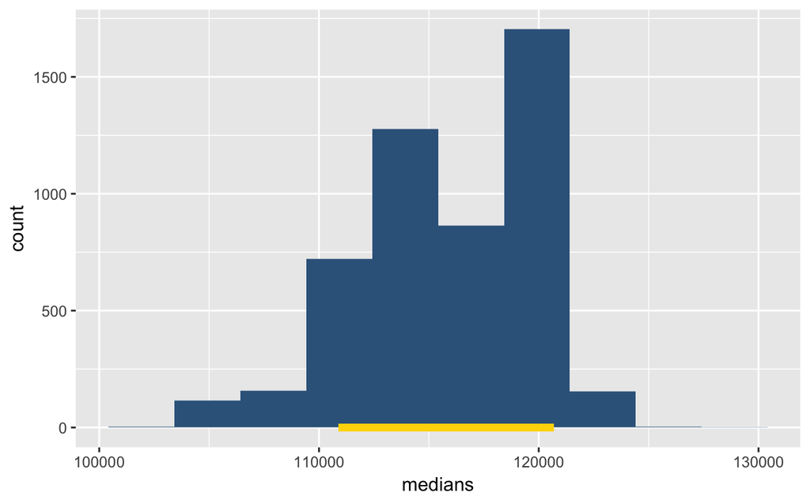